# **MATH 237 Project #2**

**Name:**  
Sean Mitani

**Research Questions:**  
After looking at the data, I was very interested in seeing how a student's daily traveling time to their school affects their own academic performance as their final grade. Then, I wanted to confirm if the time that a student takes to study a subject outside of class has any correlation with their own grade for said subject. More importantly, I would like to examine whether a student's number of fails or even a lack thereof contributes to their final grade. Lastly, I am curious to see how every student's number of absences affects their grades. As a result, I have decided to use this dataset to answer the following four research questions as listed:

1. "Could the total amount of time that a student takes to travel from their house to school have any connection with their grade?"
2. "Does the number of hours during which a student spends studying each week have an effect or impact on their grade overall?"
3. "Is there a significant relationship between the total number of times that a student fails a class and their own final grade in the end?"
4. "Would the number of times that a student misses school have any association with their grade?"

**Reasoning of Research Questions:**

1. For the first question, I was wondering if students who travel long distances to their school would consequently perform poorly. Likewise, it may be the case that students who live closer to their school earn higher grades overall.
2. As for the second question, I would imagine that students who study for longer periods of time earn better grades. Then, on the other hand, students who spend little to zero time studying would receive worse final grades or scores at the end.
3. In the third question, I wanted to check whether my belief would be right or not. As an educated guess, I think that students who fail a class one or more times actually end up doing better than their peers who passed the class the first time.
4. With the fourth question, I would just assume that students who have missed school more often than others have much lower final grades.

# **Part 1 – Data Preparation**

To begin with, I should look at the variables in every row and column of the dataset dictionary more closely.

```python
# I will import the libraries that are needed for this project.
import pandas as pd
import numpy as np
import matplotlib.pyplot as plt
import seaborn as sns
from sklearn.preprocessing import StandardScaler, LabelEncoder
from sklearn.linear_model import LinearRegression
from sklearn.model_selection import train_test_split
from sklearn.metrics import r2_score, mean_squared_error
```

```python
# In addition, I will start with directly linking this notebook to my own Google
# Drive account.
from google.colab import drive
drive.mount('/content/drive')
print("Your Google Drive account is linked to this notebook.")
```

```
Your Google Drive account is linked to this notebook.
```

```python
# On top of that, I will make sure to move the Student Performance data from my
# own Google Drive folder to this notebook.
performance = pd.read_csv('/content/drive/MyDrive/Foundations_of_Data_Science/Datasets/student-por.csv', sep = ';')
```

```python
# I will use the info() method to take a look at each type of variable in more
# detail.
performance.info()
```

```
<class 'pandas.core.frame.DataFrame'>
RangeIndex: 649 entries, 0 to 648
Data columns (total 33 columns):
 #   Column      Non-Null Count  Dtype
---  ------      --------------  -----
 0   school      649 non-null    object
 1   sex         649 non-null    object
 2   age         649 non-null    int64
 3   address     649 non-null    object
 4   famsize     649 non-null    object
 5   Pstatus     649 non-null    object
 6   Medu        649 non-null    int64
 7   Fedu        649 non-null    int64
 8   Mjob        649 non-null    object
 9   Fjob        649 non-null    object
```

[output cut: 25 more lines]

# **Part 2 – Missing Data**

Since there is no missing data for all of the features in the Student Performance dataset, I can move to the next section.

```python
# I am only interested in five of the variables and will take out all leftover
# variables from the data.
df = pd.DataFrame(performance)
performance_data = df[['traveltime', 'studytime', 'failures', 'absences', 'G3']]
print(performance_data)
```

```
     traveltime  studytime  failures  absences  G3
0             2          2         0         4  11
1             1          2         0         2  11
2             1          2         0         6  12
3             1          3         0         0  14
4             1          2         0         0  13
..          ...        ...       ...       ...  ..
644           1          3         1         4  10
645           1          2         0         4  16
646           2          2         0         6   9
647           2          1         0         6  10
648           3          1         0         4  11

[649 rows x 5 columns]
```

```python
# To see if any of these variables has missing data in them, I will look over
# them.
print("Missing Values of Each Variable")
missing_values = performance_data.isnull().sum()
print(missing_values)
```

```
Missing Values of Each Variable
traveltime    0
studytime     0
failures      0
absences      0
G3            0
dtype: int64
```

# **Part 3 – Feature Engineering**

According to this dataset, the features for traveltime and studytime are not divided into even categories. For instance, the first two categories in traveltime are meant to represent 15 minutes but the third one by itself is expanded to 30 minutes. In a similar manner, the first category in studytime features 2 hours whereas the second one suddenly increases to 3 hours. So, I will use one-hot encoding to separate them into columns for the categories that are included in the student's traveling and studying times.

```python
# Before doing anything else, I should create an additional copy of the dataset.
performance_enhanced = performance.copy()
```

```python
# For my first numerical variable, I used one-hot encoding to build new columns
# for the number of minutes that a student takes to get to their school.
print("Original Traveling Times")
print(performance_enhanced['traveltime'].value_counts())
```

```
Original Traveling Times
traveltime
1    366
2    213
3     54
4     16
Name: count, dtype: int64
```

```python
# In this case, I chose to construct four columns that were one-hot encoded with
# travel times shorter than 15 minutes, from 15 to 30 minutes, from 30 minutes
# to 1 hour, and longer than 1 hour every day.
traveltime_encoded = pd.get_dummies(performance_enhanced['traveltime'], prefix = 'traveltime')
print("One-Hot Encoded Traveling Times")
print(traveltime_encoded.head())
```

```
One-Hot Encoded Traveling Times
   traveltime_1  traveltime_2  traveltime_3  traveltime_4
0         False          True         False         False
1          True         False         False         False
2          True         False         False         False
3          True         False         False         False
4          True         False         False         False
```

```python
# Afterward, I added these four new columns to the dataset.
performance_final = pd.concat([performance_enhanced, traveltime_encoded], axis = 1)
print(f"The Student Performance dataset now has {len(performance_final.columns)} columns in total:")
print(performance_final.columns)
```

```
The Student Performance dataset now has 37 columns in total:
Index(['school', 'sex', 'age', 'address', 'famsize', 'Pstatus', 'Medu', 'Fedu',
       'Mjob', 'Fjob', 'reason', 'guardian', 'traveltime', 'studytime',
       'failures', 'schoolsup', 'famsup', 'paid', 'activities', 'nursery',
       'higher', 'internet', 'romantic', 'famrel', 'freetime', 'goout', 'Dalc',
       'Walc', 'health', 'absences', 'G1', 'G2', 'G3', 'traveltime_1',
       'traveltime_2', 'traveltime_3', 'traveltime_4'],
      dtype='object')
```

```python
# In a table, I compared the initial column with the four new versions for
# traveling times.
performance_final.head()
performance_final[['traveltime', 'traveltime_1', 'traveltime_2', 'traveltime_3', 'traveltime_4']].head()
```

|  | traveltime | traveltime_1 | traveltime_2 | traveltime_3 | traveltime_4 |
| --- | --- | --- | --- | --- | --- |
| 0 | 2 | False | True | False | False |
| 1 | 1 | True | False | False | False |
| 2 | 1 | True | False | False | False |
| 3 | 1 | True | False | False | False |
| 4 | 1 | True | False | False | False |

```python
# For my second numerical variable, I ended up also using one-hot encoding once
# again to make new columns for the number of hours that a student spends on
# studying every week.
print("Original Studying Times")
print(performance_enhanced['studytime'].value_counts())
```

```
Original Studying Times
studytime
2    305
1    212
3     97
4     35
Name: count, dtype: int64
```

```python
# Here, I decided to create four columns that were one-hot encoded with study
# times shorter than 2 hours, from 2 to 5 hours, from 5 to 10 hours, and longer
# than 10 hours per week.
studytime_encoded = pd.get_dummies(performance_enhanced['studytime'], prefix = 'studytime')
print("One-Hot Encoded Studying Times")
print(studytime_encoded.head())
```

```
One-Hot Encoded Studying Times
   studytime_1  studytime_2  studytime_3  studytime_4
0        False         True        False        False
1        False         True        False        False
2        False         True        False        False
3        False        False         True        False
4        False         True        False        False
```

```python
# Following this part, I inserted these columns into the dataset.
performance_final = pd.concat([performance_final, studytime_encoded], axis = 1)
print(f"The Student Performance dataset now has {len(performance_final.columns)} columns in total:")
print(performance_final.columns)
```

```
The Student Performance dataset now has 41 columns in total:
Index(['school', 'sex', 'age', 'address', 'famsize', 'Pstatus', 'Medu', 'Fedu',
       'Mjob', 'Fjob', 'reason', 'guardian', 'traveltime', 'studytime',
       'failures', 'schoolsup', 'famsup', 'paid', 'activities', 'nursery',
       'higher', 'internet', 'romantic', 'famrel', 'freetime', 'goout', 'Dalc',
       'Walc', 'health', 'absences', 'G1', 'G2', 'G3', 'traveltime_1',
       'traveltime_2', 'traveltime_3', 'traveltime_4', 'studytime_1',
       'studytime_2', 'studytime_3', 'studytime_4'],
      dtype='object')
```

```python
# In a table, I compared the original column with the four new versions for
# studying times.
performance_final.head()
performance_final[['studytime', 'studytime_1', 'studytime_2', 'studytime_3', 'studytime_4']].head()
```

|  | studytime | studytime_1 | studytime_2 | studytime_3 | studytime_4 |
| --- | --- | --- | --- | --- | --- |
| 0 | 2 | False | True | False | False |
| 1 | 2 | False | True | False | False |
| 2 | 2 | False | True | False | False |
| 3 | 3 | False | False | True | False |
| 4 | 2 | False | True | False | False |

```python
# Ultimately, in order to prevent any problems with the algorithms, I will
# remove the two columns that I worked with.
performance_final = performance_final.drop(['traveltime', 'studytime'], axis = 1)
```

```python
# For my final numerical variable, I chose to instead use binning to break apart
# the total number of times that a student misses a class, if any.
performance_enhanced['Absence_Categories'] = pd.cut(performance_enhanced['absences'],
                                                    bins = [-1, 0, 3, 6, 9],
                                                    labels = ['No Absences', 'Low Absences', 'Moderate Absences', 'High Absences'])
```

```python
# I will show how this new feature works for the first five rows of the data.
performance_enhanced[['absences', 'Absence_Categories']].head()
```

|  | absences | Absence_Categories |
| --- | --- | --- |
| 0 | 4 | Moderate Absences |
| 1 | 2 | Low Absences |
| 2 | 6 | Moderate Absences |
| 3 | 0 | No Absences |
| 4 | 0 | No Absences |

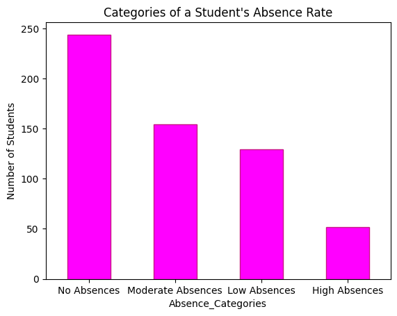

```python
# As such, I will build a bar plot with pink bars to display the different
# categories for the number of absences.
performance_enhanced['Absence_Categories'].value_counts().plot(kind = 'bar',
                                                               color = 'fuchsia',
                                                               edgecolor = 'mediumvioletred')
plt.title("Categories of a Student's Absence Rate")
plt.ylabel('Number of Students')
plt.tick_params(axis = 'x', rotation = 0)
```

**Observation:**

- For this bar plot in pink, its main shape looks to be skewed to the right and the absence category that shows up on the graph the most frequently is no absences.

```
Old Feature Scales
failures: 0.0 to 3.0
absences: 0.0 to 32.0

New Feature Scales
failures_scaled: -0.37 to 4.69
absences_scaled: -0.79 to 6.11
```

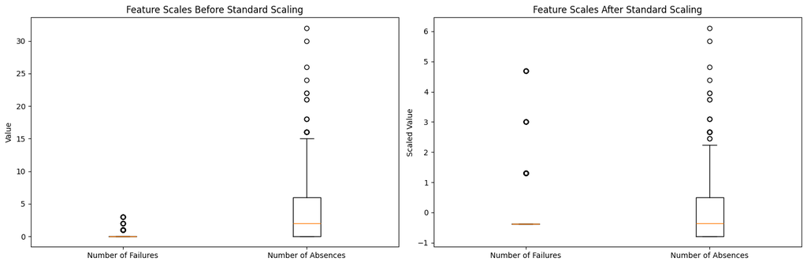

```python
# First, I will list the original feature scales for both the number of failures
# and absences.
print("Old Feature Scales")
numeric_cols = ['failures', 'absences']
for col in numeric_cols:
  print(f"{col}: {performance_final[col].min():.1f} to {performance_final[col].max():.1f}")

# In this instance, I will stick to standard scaling with a mean equal to 0 and
# a standard deviation equal to 1.
scaler = StandardScaler()
scaled_features = scaler.fit_transform(performance_final[numeric_cols])
scaled_df = pd.DataFrame(scaled_features, columns = [f'{col}_scaled' for col in numeric_cols])

# Then, I will display the resulting feature scales for both the number of
# failures and absences.
print("\nNew Feature Scales")
for col in scaled_df.columns:
  print(f"{col}: {scaled_df[col].min():.2f} to {scaled_df[col].max():.2f}")

# I will include these scaled features in the initial dataset.
performance_final = pd.concat([performance_final, scaled_df], axis = 1)

# To picture this, I will generate graphs with the old and new feature scales.
fig, (ax1, ax2) = plt.subplots(1, 2, figsize = (15, 5))
ax1.boxplot([performance_final['failures'], performance_final['absences']])
ax1.set_xticklabels(['Number of Failures', 'Number of Absences'])
ax1.set_title('Feature Scales Before Standard Scaling')
ax1.set_ylabel('Value')
ax2.boxplot([performance_final['failures_scaled'], performance_final['absences_scaled']])
ax2.set_xticklabels(['Number of Failures', 'Number of Absences'])
ax2.set_title('Feature Scales After Standard Scaling')
ax2.set_ylabel('Scaled Value')
plt.tight_layout()
plt.show()
```

Apart from seeing their overall effect on a student's academic performance, I will explore how these variables interact with each other directly. To help answer my four questions, I will create three new feature interactions with all features. For the first relation, I will see if those who failed a class frequently spent more time studying in an attempt to catch up. In the second interaction, I would like to mainly explore whether students who spend more time traveling to school skipped class more often or not as a result. As the third relation, I want to look into if those who studied for many hours per week were more likely to show up.

```python
# 1. Interaction Between Studying Time and Number of Failures:
performance_final['StudyTime_Failures_Interaction'] = performance_enhanced['studytime'] * performance_final['failures']

# 2. Interaction Between Traveling Time and Number of Absences:
performance_final['TravelTime_Absences_Interaction'] = performance_enhanced['traveltime'] * performance_final['absences']

# 3. Interaction Between Studying Time and Number of Absences:
performance_final['StudyTime_Absences_Interaction'] = performance_enhanced['studytime'] * performance_final['absences']
print("All three of these interaction features were made successfully.")
```

```
All three of these interaction features were made successfully.
```

```python
# Last but not least, I will create a rather brief overview of all the feature
# engineering that has been completed.
print("Overview of All the Feature Engineering")
old_features = list(performance.columns)
all_features = list(performance_final.columns)
new_features = [col for col in all_features if col not in old_features]
print(f"\nOld Features ({len(old_features)}): {old_features}")
print(f"New Features ({len(new_features)}):")
for i, feature in enumerate(new_features, 1):
  print(f"  {i:2d}. {feature}")
print(f"\nNumber of All Features: {len(old_features)} original features to {len(all_features)} current features")
print(f"Number of New Features: {len(all_features) - len(old_features)} new features")
```

```
Overview of All the Feature Engineering

Old Features (33): ['school', 'sex', 'age', 'address', 'famsize', 'Pstatus', 'Medu', 'Fedu', 'Mjob', 'Fjob', 'reason', 'guardian', 'traveltime', 'studytime', 'failures', 'schoolsup', 'famsup', 'paid', 'activities', 'nursery', 'higher', 'internet', 'romantic', 'famrel', 'freetime', 'goout', 'Dalc', '…
New Features (13):
   1. traveltime_1
   2. traveltime_2
   3. traveltime_3
   4. traveltime_4
   5. studytime_1
   6. studytime_2
   7. studytime_3
   8. studytime_4
   9. failures_scaled
  10. absences_scaled
  11. StudyTime_Failures_Interaction
  12. TravelTime_Absences_Interaction
  13. StudyTime_Absences_Interaction

Number of All Features: 33 original features to 44 current features
Number of New Features: 11 new features
```

# **Part 4 – Data Plots**

In this part, I will make:

1. Two bar plots to look for possible balances between the times that a student spends traveling to their school and studying.
2. Two boxplots to check or see if any kind of pattern is present when comparing the times that a student spends traveling to their school and studying with their final grade.
3. Two histograms to help view the overall shape of the distrbutions for both the student's number for failures and absences.
4. Two scatterplots to confirm if a trend appears to exist while comparing a student's number of failures and absences with their final grade altogether.

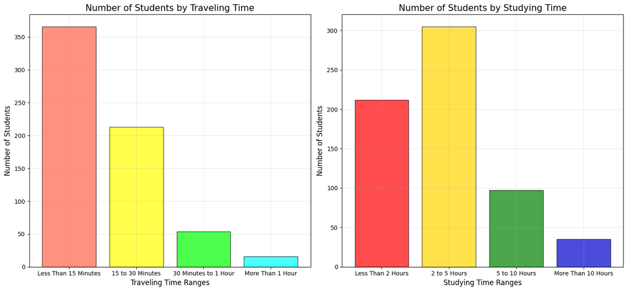

```python
fig, axes = plt.subplots(1, 2, figsize = (15, 7))

# 1. As the first graph, I will assemble a bar plot with red, yellow, green, and
#    blue bars in neon to convey the counts of the students by times that they
#    took traveling each day.
traveltime_cols = ['traveltime_1', 'traveltime_2', 'traveltime_3', 'traveltime_4']
traveltime_counts = performance_final[traveltime_cols].sum()
traveltime_colors = ['tomato', 'yellow', 'lime', 'cyan']
x_labels_travel = ['Less Than 15 Minutes', '15 to 30 Minutes', '30 Minutes to 1 Hour', 'More Than 1 Hour']
axes[0].bar(x_labels_travel, traveltime_counts.values, color = traveltime_colors, alpha = 0.7, edgecolor = 'black')
axes[0].set_title('Number of Students by Traveling Time', fontsize = 15)
axes[0].set_xlabel('Traveling Time Ranges', fontsize = 12)
axes[0].set_ylabel('Number of Students', fontsize = 12)
axes[0].grid(True, alpha = 0.3)
axes[0].tick_params(axis = 'x', rotation = 0)

# 2. As the next graph, I will build a bar plot with red, yellow, green, and
#    blue bars in darker shades to help convey the counts of the students by
#    times that they spent studying every week.
studytime_cols = ['studytime_1', 'studytime_2', 'studytime_3', 'studytime_4']
studytime_counts = performance_final[studytime_cols].sum()
studytime_colors = ['red', 'gold', 'green', 'mediumblue']
x_labels_study = ['Less Than 2 Hours', '2 to 5 Hours', '5 to 10 Hours', 'More Than 10 Hours']
axes[1].bar(x_labels_study, studytime_counts.values, color = studytime_colors, alpha = 0.7, edgecolor = 'black')
axes[1].set_title('Number of Students by Studying Time', fontsize = 15)
axes[1].set_xlabel('Studying Time Ranges', fontsize = 12)
axes[1].set_ylabel('Number of Students', fontsize = 12)
axes[1].grid(True, alpha = 0.3)
axes[1].tick_params(axis = 'x', rotation = 0)
plt.tight_layout()
plt.show()
```

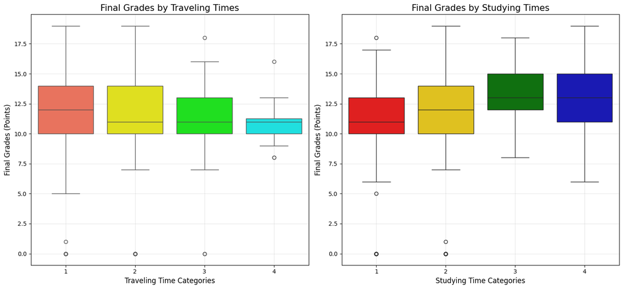

```python
fig, axes = plt.subplots(1, 2, figsize = (15, 7))

# 1. In the first graph, I will make a boxplot with red, yellow, green, and blue
#    bars in neon to mainly show how strong the relationship is between the time
#    that a student takes to travel to their school and their final grade in the
#    end.
sns.boxplot(data = performance_enhanced, x = 'traveltime', y = 'G3', hue = 'traveltime', palette = ['tomato', 'yellow', 'lime', 'cyan'], legend = False, ax = axes[0])
axes[0].set_title('Final Grades by Traveling Times', fontsize = 15)
axes[0].set_xlabel('Traveling Time Categories', fontsize = 12)
axes[0].set_ylabel('Final Grades (Points)', fontsize = 12)
axes[0].grid(True, alpha = 0.3)

# 2. In the second graph, I will use a boxplot with red, yellow, green, and blue
#    bars in darker shades to signify how strong the relationship is between the
#    time that a student spends studying on a weekly basis and their own grade.
sns.boxplot(data = performance_enhanced, x = 'studytime', y = 'G3', hue = 'studytime', palette = ['red', 'gold', 'green', 'mediumblue'], legend = False, ax = axes[1])
axes[1].set_title('Final Grades by Studying Times', fontsize = 15)
axes[1].set_xlabel('Studying Time Categories', fontsize = 12)
axes[1].set_ylabel('Final Grades (Points)', fontsize = 12)
axes[1].grid(True, alpha = 0.3)
plt.tight_layout()
plt.show()
```

**Observations:**

- Based on the boxplot from the first graph in neon red, yellow, green, and blue, the grades become lower while their own interquartile ranges shrink as the traveling times increase.
- Additionally, the highest average grade comes from students who were all grouped within the first traveling time category.
- Based on the boxplot from the second graph in dark red, yellow, green, and blue, the grades become higher yet their interquartile ranges have no change as the studying times increase.
- However, the highest average grade for this case looks like it belongs to those who were placed in both the third and fourth studying time categories with the same grade.
- Although there are a few outliers in both graphs, their presence would affect neither the IQR nor the median grade.

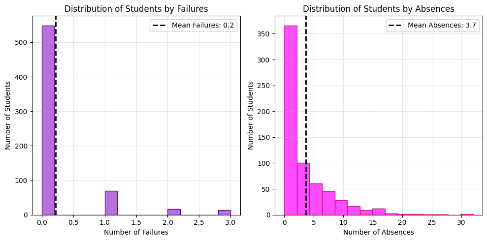

```python
fig, axes = plt.subplots(1, 2, figsize = (10, 5))

# 1. For the first graph, I will form a histogram with purple bars to display
#    the full distribution of the students according to the times that they have
#    failed a class.
sns.histplot(performance_final['failures'], bins = 15, color = 'darkorchid', alpha = 0.7, edgecolor = 'indigo', ax = axes[0])
mean_failures = performance_final['failures'].mean()
axes[0].axvline(mean_failures, color = 'black', linestyle = '--', linewidth = 2, label = f'Mean Failures: {mean_failures:.1f}')
axes[0].set_title('Distribution of Students by Failures')
axes[0].set_xlabel('Number of Failures')
axes[0].set_ylabel('Number of Students')
axes[0].grid(True, alpha = 0.3)
axes[0].legend()

# 2. For the second graph, I will make a histogram with pink bars to display the
#    full distribution of the students based on the times that they have been
#    absent from school.
sns.histplot(performance_final['absences'], bins = 15, color = 'fuchsia', alpha = 0.7, edgecolor = 'mediumvioletred', ax = axes[1])
mean_absences = performance_final['absences'].mean()
axes[1].axvline(mean_absences, color = 'black', linestyle = '--', linewidth = 2, label = f'Mean Absences: {mean_absences:.1f}')
axes[1].set_title('Distribution of Students by Absences')
axes[1].set_xlabel('Number of Absences')
axes[1].set_ylabel('Number of Students')
axes[1].grid(True, alpha = 0.3)
axes[1].legend()
plt.tight_layout()
plt.show()
```

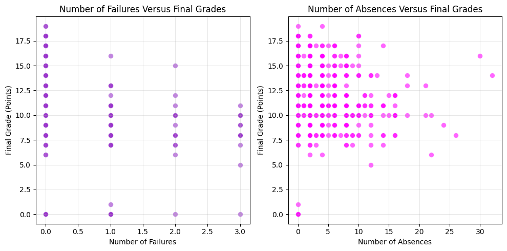

```python
fig, axes = plt.subplots(1, 2, figsize = (10, 5))

# 1. Through the first graph, I will construct a scatterplot with purple points
#    to highlight the relationship between the students' number of failures and
#    their own final grades.
sns.scatterplot(x = performance_final['failures'], y = performance_final['G3'], color = 'darkorchid', alpha = 0.6, s = 50, ax = axes[0])
axes[0].set_title('Number of Failures Versus Final Grades')
axes[0].set_xlabel('Number of Failures')
axes[0].set_ylabel('Final Grade (Points)')
axes[0].grid(True, alpha = 0.3)

# 2. Through the second graph, I will create a scatterplot with pink points to
#    highlight the relationship between the student's number of absences and
#    their final grades.
sns.scatterplot(x = performance_final['absences'], y = performance_final['G3'], color = 'fuchsia', alpha = 0.6, s = 50, ax = axes[1])
axes[1].set_title('Number of Absences Versus Final Grades')
axes[1].set_xlabel('Number of Absences')
axes[1].set_ylabel('Final Grade (Points)')
axes[1].grid(True, alpha = 0.3)
plt.tight_layout()
plt.show()
```

**Observations:**

- According to the first scatterplot in purple, there appears to be a rather weak negative correlation between the total number of times that a student has failed a class and their own final grade at the end.
- Therefore, the students who failed a previous class little to no times will have higher final grades whereas those who failed the same class multiple times would have much lower grades.
- According to the second scatterplot in pink, there does not seem to be any correlation at all between the total number of times that a student was absent from the school and their own final grade at the end.
- Instead, the graph looks like it has a cluster of students who have higher final grades with lower absences anywhere from 0 to 10 times.

# **Part 5 – Multiple Linear Regression**

The features that I will focus on for $x$ are:

1. The total time that a student takes getting to school each day in minutes.
2. The total time that a student spends studying for class every week in hours.
3. The total number of times that a student has failed a previous class.
4. The total number of times that a student has missed a class or skipped school.

Putting this all together, the model for the multiple linear regression will look like:  
Predicted Final Grade $ = b_0 + b_1($traveltime$) + b_2($studytime$) + b_3($failures$) + b_4($absences$)$  
where $b_0$, $b_1$, $b_2$, $b_3$, along with $b_4$ are parameters in this model.

```python
# I will move these five variables so that they correspond to both the x and y
# components.
x = performance_enhanced[['traveltime', 'studytime', 'failures', 'absences']]
y = performance_enhanced['G3']
```

```python
# I will also use the standard 80-20 split to help separate the dataset into the
# training and test sets.
X_train, X_test, y_train, y_test = train_test_split(x, y, test_size = 0.2, random_state = 10)

print(f"Training Set Size: {len(X_train)} samples")
print(f"Test Set Size: {len(X_test)} samples")

y_train.info()
```

```
Training Set Size: 519 samples
Test Set Size: 130 samples
<class 'pandas.core.series.Series'>
Index: 519 entries, 510 to 265
Series name: G3
Non-Null Count  Dtype
--------------  -----
519 non-null    int64
dtypes: int64(1)
memory usage: 8.1 KB
```

```python
# As the first step, I will only make a single correlation matrix for the
# model's target.
train_data = performance_data.copy()
correlation_matrix = train_data.corr(numeric_only=True)
print(correlation_matrix['G3'].sort_values(key = abs, ascending = False))
```

```
G3            1.000000
failures     -0.393316
studytime     0.249789
traveltime   -0.127173
absences     -0.091379
Name: G3, dtype: float64
```

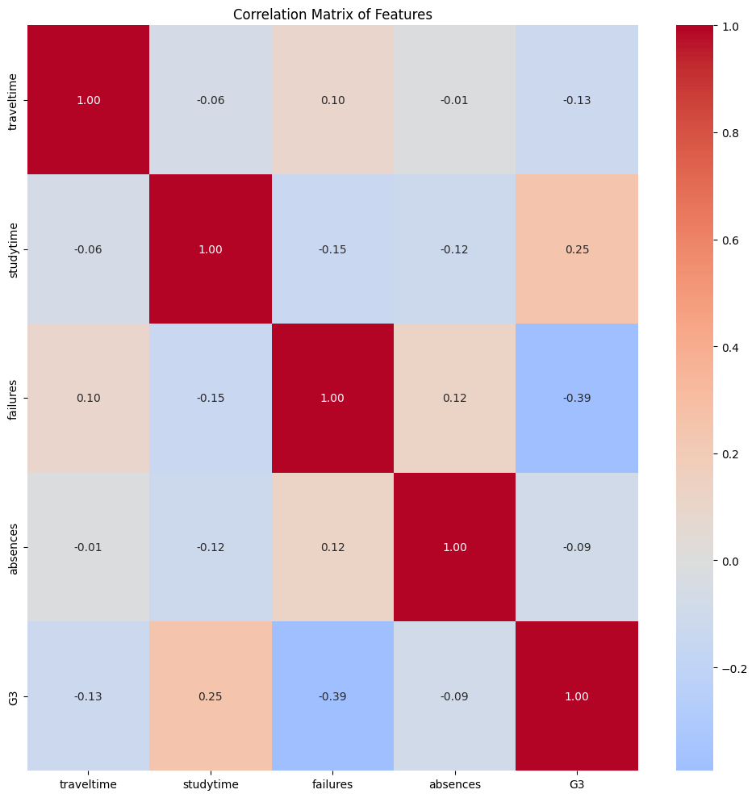

```python
# However, I will now also make another correlation matrix for the model's
# features.
plt.figure(figsize = (10, 10))
sns.heatmap(correlation_matrix, annot = True, fmt = '.2f', cmap = 'coolwarm', center = 0)
plt.title('Correlation Matrix of Features')
plt.tight_layout()
plt.show()
```

```python
# I will create the scaler and only fit it on the train set.
scaler = StandardScaler()
X_train_scaled = scaler.fit_transform(X_train)

# This time, I will apply the same transformation again but avoid fitting it on
# the test set.
X_test_scaled = scaler.transform(X_test)
feature_columns = x.columns

# In addition, I will convert these components back to the DataFrame to keep the
# column names.
X_train_scaled = pd.DataFrame(X_train_scaled, columns = feature_columns, index = X_train.index)
X_test_scaled = pd.DataFrame(X_test_scaled, columns = feature_columns, index = X_test.index)
```

```python
# Above all else, I will make and train this model on scaled data.
model = LinearRegression()
model.fit(X_train_scaled, y_train)
```

```
LinearRegression()
```

```python
# I will take out all four features and lay out their coefficients.
intercept = model.intercept_
coefficients = model.coef_

coef_df = pd.DataFrame({
    'Feature': feature_columns,
    'Coefficient': coefficients
}).sort_values('Coefficient', key = abs, ascending = False)

print(f"Intercept: {intercept:.1f}")
print("\nCoefficients (Arranged by Absolute Value)")
print(coef_df)
```

```
Intercept: 12.0

Coefficients (Arranged by Absolute Value)
      Feature  Coefficient
2    failures    -1.201964
1   studytime     0.528660
0  traveltime    -0.209691
3    absences    -0.143085
```

```python
# To wrap everything up, I will combine all these coefficients into a single
# equation.
print(f"Predicted Final Grade = {intercept:.1f} points + {coefficients[0]:.1f} points(traveltime) + {coefficients[1]:.1f} points(studytime) + {coefficients[2]:.1f} points(failures) + {coefficients[3]:.1f} points(absences)")
```

```
Predicted Final Grade = 12.0 points + -0.2 points(traveltime) + 0.5 points(studytime) + -1.2 points(failures) + -0.1 points(absences)
```

```python
# I will use the equation to interpret the intercept and coefficients in this
# context.
print("Interpretation of All Coefficients on Scaled Data")
print(f"Intercept: {intercept:.0f} points")
print(" • The average final grade when all four features are at their mean values.\n")

for feature, coef in zip(x.columns, coefficients):
  print(f"{feature}: {coef:.1f} points")
  print(f" • When {feature} increases by 1 standard deviation, the final grade")
  print(f"   increases by about {coef:.1f} points, holding other variables constant.\n")
```

```
Interpretation of All Coefficients on Scaled Data
Intercept: 12 points
 • The average final grade when all four features are at their mean values.

traveltime: -0.2 points
 • When traveltime increases by 1 standard deviation, the final grade
   increases by about -0.2 points, holding other variables constant.

studytime: 0.5 points
 • When studytime increases by 1 standard deviation, the final grade
   increases by about 0.5 points, holding other variables constant.

failures: -1.2 points
 • When failures increases by 1 standard deviation, the final grade
   increases by about -1.2 points, holding other variables constant.

absences: -0.1 points
 • When absences increases by 1 standard deviation, the final grade
   increases by about -0.1 points, holding other variables constant.
```

```python
# I will assess the new multiple regression model by checking the training set's
# performance.
y_train_pred = model.predict(X_train_scaled)
r2_train = r2_score(y_train, y_train_pred)
mse_train = mean_squared_error(y_train, y_train_pred)
rmse_train = np.sqrt(mse_train)

print("Training Set Performance")
print(f" • R-Squared Value: {r2_train:.4f}")
print(f" • Mean Squared Error: {mse_train:.4f}")
print(f" • Root Mean Squared Error: {rmse_train:.4f}")
```

```
Training Set Performance
 • R-Squared Value: 0.2011
 • Mean Squared Error: 8.4691
 • Root Mean Squared Error: 2.9102
```

```python
# Likewise, I will also evaluate this new multiple regression model by reviewing
# the test set's performance.
y_test_pred = model.predict(X_test_scaled)
r2_test = r2_score(y_test, y_test_pred)
mse_test = mean_squared_error(y_test, y_test_pred)
rmse_test = np.sqrt(mse_test)

print("Test Set Performance")
print(f" • R-Squared Value: {r2_test:.4f}")
print(f" • Mean Squared Error: {mse_test:.4f}")
print(f" • Root Mean Squared Error: {rmse_test:.4f}")
```

```
Test Set Performance
 • R-Squared Value: 0.1680
 • Mean Squared Error: 7.9907
 • Root Mean Squared Error: 2.8268
```

**Application of the Model:**  
Lastly, I will use this multiple regression model to predict the final grade for a high school student who...

- took 14 minutes to travel to school each day,
- spent 6 hours studying outside of class every week,
- failed a class 1 time, and
- was absent from school for a total of 12 times.

```python
# I will see how well this multiple regression model is by using the given
# example.
prediction_x = pd.DataFrame({
    'traveltime': [1],
    'studytime': [3],
    'failures': [1],
    'absences': [12]
})
prediction_x_scaled = scaler.transform(prediction_x)
prediction_x_scaled = pd.DataFrame(prediction_x_scaled, columns = x.columns)
prediction_y = model.predict(prediction_x_scaled)
print(f"As it turns out, the true final grade for this student would be roughly {prediction_y[0]:.1f} points.")
```

```
As it turns out, the true final grade for this student would be roughly 10.9 points.
```

```python
# To check its precision, I will manually make sure that this model's prediction
# is correct.
manual_prediction = intercept + np.sum(coefficients * prediction_x_scaled.values[0])
print(f"Manual Prediction: {manual_prediction:.1f} points")
print(f"Model Prediction: {prediction_y[0]:.1f} points")
print(f"Match Between Both Predictions: {np.isclose(manual_prediction, prediction_y[0])}")
```

```
Manual Prediction: 10.9 points
Model Prediction: 10.9 points
Match Between Both Predictions: True
```

# **Part 6 – Ethical Concerns and Data Limitations**

First, an ethical concern that I have is if informed consent was present throughout the study, primarily while taking the participants' information. Although I can assume that the students gave their consent prior to filling out the questionnnaires, I cannot necessarily say the same for school reports since these do not need their permission. Speaking of the students' data, another concern would be that some variables like family relationships can contain sensitive details in nature. If this type of information was to be leaked in any way, it would most certainly be both damaging and devastating for the students from these two schools. Lastly, even other features which are not as sensitive such as the amount of free time that a student has after classes can cause harm in certain models. Moreover, this may lead to the false assumption that just having lots of free time can result in lower grades and worse performance.  
Next, one data limitation is the lack of variety in both the high schools and subjects that were used for this dataset. Among all the countless private and public types of schools in Portugal, the data was only taken from two high schools. Even though these two high schools were not specified, I believe it is safe to say that they did not provide a proper representation of all schools throughout Portugal. Thus, this study could be improved by including a diverse and larger sample of schools from various neighborhoods or regions in the country. Similarly, the scope of this study was only designed with two fields in mind: Mathematics and Portugese language. It would have been nice to investigate other subjects including history, physical education, and science. Above all else, the ranges for some numeric variables were not consistent or equal with each other, most notably the pair between traveling times and studying times in this project. To add to this problem, some ranges such as the second one from 2 to 5 hours for studying times can be too general in their lengths because the actual time that was used to study could be as short as 2 hours or much longer as 4 hours. So, I believe that this study can be changed with other ranges that are not only narrower but also even such as less than 1 hour, 1 to 2 hours, and so on.

```python
# Convert this notebook to HTML.
!jupyter nbconvert --to html "/content/drive/MyDrive/Foundations_of_Data_Science/Projects/MATH237Project2.ipynb" --output project2
```

```
[NbConvertApp] Converting notebook /content/drive/MyDrive/Foundations_of_Data_Science/Projects/MATH237Project2.ipynb to html
[NbConvertApp] Writing 388194 bytes to /content/drive/MyDrive/Foundations_of_Data_Science/Projects/project2.html
```